# RM_HW_W8

Rekha Murali

3/7/2019

# Problem 1

## 1.1 Three properties of RNA-seq read count data and adjustments:

Raw counts can be heavily influenced by a lot of factors such as sequencing depth, gene length, and individual gene abundances. Because of these factors the raw counts need to be normalized and adjusted to more accurately reflect actual number of captured transcripts. You could use TPM to adjust for the effect of gene length. Additionally, rlog is useful because you can normalize for small gene counts and library size so that helps correct for individual gene abundances. One way to normalize for sequencing depth is the DESeq2 function estimateSizeFactors().

# Problem 2

## 2.1 Exploring functions

### Use help documentation to find information about the functions

```r
suppressPackageStartupMessages(library(DESeq2))
?rlog
?DESeqDataSetFromMatrix
```

### Output:

These are the arguments required for the DESeqDataSetFromMatrix function:

- DESeqDataSetFromMatrix(countData, colData, design, tidy = FALSE, ignoreRank = FALSE, …)

These are the arguments required for the rlog function:

- rlog(object, blind = TRUE, intercept, betaPriorVar, fitType = “parametric”)

### Use class/showClass function on S4 objects

```r
# this is the rlog transformed data we created in class using rlog()
rlogDS <- readRDS("/Users/rekhamurali/Desktop/ANGSD/ANGSD_2/rlog.rds")

# this is the DESeq object we created in class using DESeqDataSetFromMatrix()
deseqDS <- readRDS("/Users/rekhamurali/Desktop/ANGSD/ANGSD_2/DESeq.rds")

showClass(class(rlogDS))
```

```
## Class "DESeqTransform" [package "DESeq2"]
##
## Slots:
##
## Name:                     rowRanges                      colData
## Class: GenomicRanges_OR_GRangesList                    DataFrame
##
## Name:                        assays                        NAMES
## Class:                       Assays            character_OR_NULL
##
## Name:               elementMetadata                     metadata
## Class:                    DataFrame                         list
##
## Extends:
## Class "RangedSummarizedExperiment", directly
## Class "SummarizedExperiment", by class "RangedSummarizedExperiment", distance 2
## Class "Vector", by class "RangedSummarizedExperiment", distance 3
## Class "Annotated", by class "RangedSummarizedExperiment", distance 4
```

```r
showClass(class(deseqDS))
```

```
## Class "DESeqDataSet" [package "DESeq2"]
##
## Slots:
##
## Name:                        design           dispersionFunction
## Class:                          ANY                     function
##
## Name:                     rowRanges                      colData
## Class: GenomicRanges_OR_GRangesList                    DataFrame
##
## Name:                        assays                        NAMES
## Class:                       Assays            character_OR_NULL
##
## Name:               elementMetadata                     metadata
## Class:                    DataFrame                         list
##
## Extends:
## Class "RangedSummarizedExperiment", directly
## Class "SummarizedExperiment", by class "RangedSummarizedExperiment", distance 2
## Class "Vector", by class "RangedSummarizedExperiment", distance 3
## Class "Annotated", by class "RangedSummarizedExperiment", distance 4
```

### Explanation:

The DESeqDataSetFromMatrix() function creates a DESeq object from a raw counts matrix and colData, which is a data frame that you create specifying your conditions to be compared. The rlog() function transforms the count data to the log2scale and minimizes the differenes in small counts and normalizes with respect to library size.

Two Similarties:

Two Differences:

- Rlog is transformed data, rlog is used to normalize your data, whereas you still need to normalize after creating the dds object with the other function
- you need to run DESeqDataSetFromMatrix() first because the output (dds) is what you use for input to rlog()

## 2.2 Find expression values

```
# use head() for easier visualization of counts
# assay is the slot that stores the counts
# use it as a function to return the counts
assay(deseqDS)
assay(rlogDS)
```

## 2.3 Create a new matrix

```r
# add a matrix to my object
# adding to the metadata slot
rlogDS@metadata$my_personal_normalization <- assay(rlogDS)
```

## 2.4 PCA and dendrogram plots

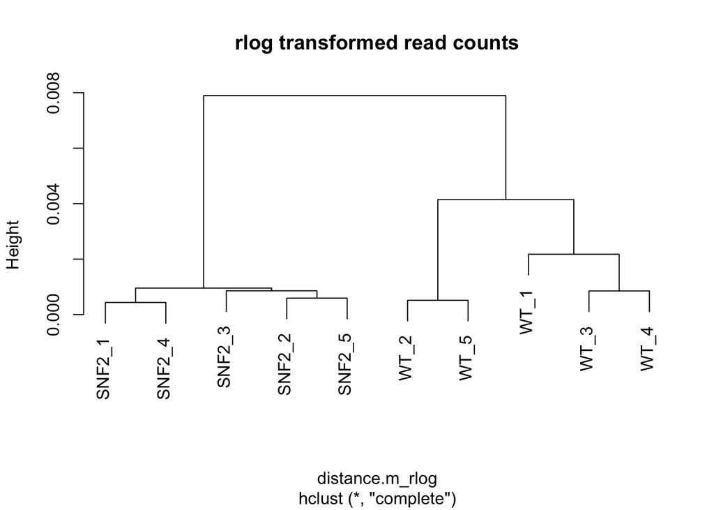

```r
# rlog counts from class
rlog.norm.counts <- readRDS("/Users/rekhamurali/Desktop/ANGSD/ANGSD_2/rlog.norm.counts.rds")

# dendogram plot using pearson distance
pw_cor <- cor(rlog.norm.counts, method = "pearson")
distance.m_rlog <- as.dist(1-pw_cor)
plot(hclust(distance.m_rlog),labels=colnames(rlog.norm.counts),main="rlog transformed read counts")
```

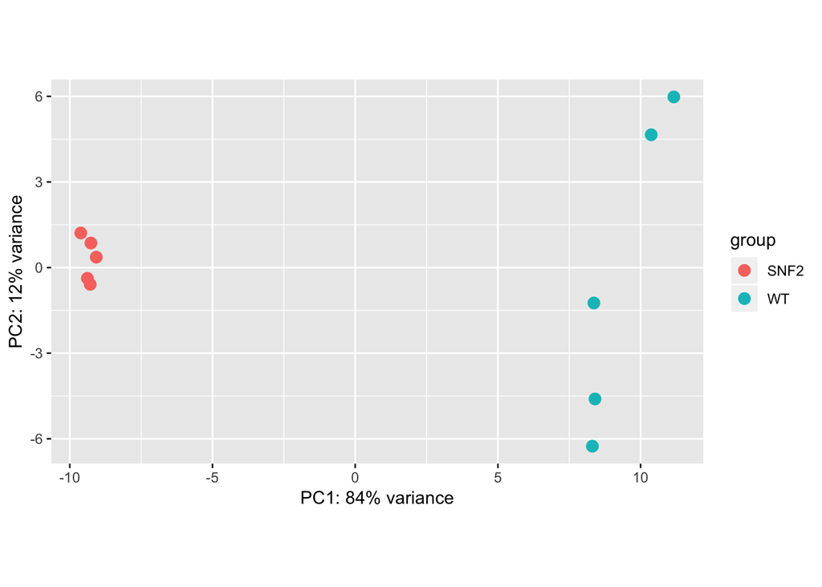

```
# PCA explorer
pcaExplorer::pcaExplorer(dds=deseqDS ,dst=rlogDS)
```

```r
# PCA plot
plotPCA(rlogDS, intgroup=c("condition"))
```

### Explanation

Another one of the plots/visualizations in pcaExplorer under the sample section is the top and bottom loadings plot for each PC. I think that the loadings represent the variable genes that define that PC. In particular, the top loadings might be the genes that are higher expressed in that PC.